# DRILL - Exploring the Central Limit Theorem

```python
import numpy as np
import pandas as pd
import scipy
import matplotlib.pyplot as plt
%matplotlib inline
```

```python
# Create two binomially distributed populations with n equal to 10 and size equal to 10000.
# The p-value of pop1 should be 0.2 and the p-value of pop2 should be 0.5
pop1 = np.random.binomial(10, 0.2, 10000)
pop2 = np.random.binomial(10,0.5, 10000)
```

```python
# Using a sample size of 100, calculate the means and standard deviations of your samples.
sample1 = np.random.choice(pop1, 100)
sample2 = np.random.choice(pop2, 100)

print("S1 --- Mean:", sample1.mean(), "Std:", sample1.std())
print("S2 --- Mean:", sample2.mean(), "Std:", sample2.std())
```

```
S1 --- Mean: 2.03 Std: 1.12654338576
S2 --- Mean: 5.17 Std: 1.56878934214
```

### Increase the size of your samples from 100 to 1000, then calculate the means and standard deviations for your new samples and create histograms for each. Repeat this again, decreasing the size of your samples to 20. What values change, and what remain the same?

#### Expectations

Sample size 1000 Mean will move closer to p-value and the standard deviation will decrease

Sample size 20 Mean will move further away from p-value and standard deviation will increase

#### Reality

```
S1 --- Mean: 2.024 Std: 1.27961869321
S2 --- Mean: 4.991 Std: 1.49830537608
```

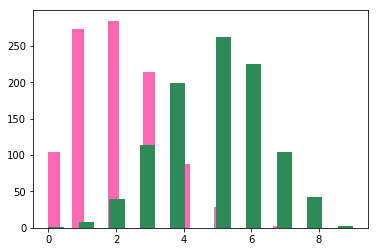

```python
#Population 1000
sample1 = np.random.choice(pop1, 1000)
sample2 = np.random.choice(pop2, 1000)

print("S1 --- Mean:", sample1.mean(), "Std:", sample1.std())
print("S2 --- Mean:", sample2.mean(), "Std:", sample2.std())

plt.hist(sample1, bins=20, color="hotpink")
plt.hist(sample2, bins=20, color="seagreen")
plt.show()
```

```
S1 --- Mean: 2.15 Std: 1.15217186218
S2 --- Mean: 4.95 Std: 1.2835497653
```

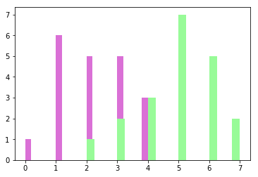

```python
#Population 20
sample1 = np.random.choice(pop1, 20)
sample2 = np.random.choice(pop2, 20)

print("S1 --- Mean:", sample1.mean(), "Std:", sample1.std())
print("S2 --- Mean:", sample2.mean(), "Std:", sample2.std())

plt.hist(sample1, bins=20, color="orchid")
plt.hist(sample2, bins=20, color="palegreen")
plt.show()
```

Predictions were close but the standard deviation acted opposite of what I expected

### Change the population value (p in the NumPy documentation) for pop1 to 0.3, then take new samples and compute the t-statistic and p-value. Then change the population value p for group 1 to 0.4, and do it again. What changes, and why?

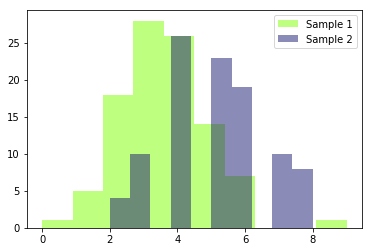

```
Ttest_indResult(statistic=7.3880631267064603, pvalue=4.1270825036512524e-12)
```

```python
pop1 = np.random.binomial(10, 0.3, 10000)
pop2 = np.random.binomial(10,0.5, 10000)

sample1 = np.random.choice(pop1, 100, replace=True)
sample2 = np.random.choice(pop2, 100, replace=True)

plt.hist(sample1, alpha=0.5, label='Sample 1', color="chartreuse")
plt.hist(sample2, alpha=0.5, label='Sample 2', color="midnightblue")
plt.legend(loc='upper right')
plt.show()

from scipy.stats import ttest_ind
print(ttest_ind(sample2, sample1, equal_var=False))
```

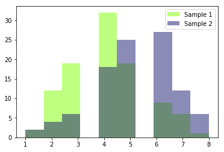

```
Ttest_indResult(statistic=5.1447225241801684, pvalue=6.4428698901092275e-07)
```

```python
pop1 = np.random.binomial(10, 0.4, 10000)
pop2 = np.random.binomial(10,0.5, 10000)

sample1 = np.random.choice(pop1, 100, replace=True)
sample2 = np.random.choice(pop2, 100, replace=True)

plt.hist(sample1, alpha=0.5, label='Sample 1', color="chartreuse")
plt.hist(sample2, alpha=0.5, label='Sample 2', color="midnightblue")
plt.legend(loc='upper right')
plt.show()

from scipy.stats import ttest_ind
print(ttest_ind(sample2, sample1, equal_var=False))
```

The T-statistic decreases and the pvalue increases when the samples become more similar.

### Change the distribution of your populations from binomial to a distribution of your choice. Do the sample mean values still accurately represent the population values?

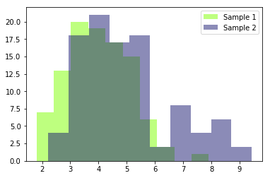

```
Ttest_indResult(statistic=4.8392238415518811, pvalue=2.8349883256178401e-06)
S1 --- Mean: 4.00925029692 Std: 1.12753373368
S2 --- Mean: 4.97296700669 Std: 1.62940457781
```

```python
pop1 = np.random.gamma(10, 0.4, 10000)
pop2 = np.random.gamma(10,0.5, 10000)

sample1 = np.random.choice(pop1, 100, replace=True)
sample2 = np.random.choice(pop2, 100, replace=True)

plt.hist(sample1, alpha=0.5, label='Sample 1', color="chartreuse")
plt.hist(sample2, alpha=0.5, label='Sample 2', color="midnightblue")
plt.legend(loc='upper right')
plt.show()

from scipy.stats import ttest_ind
print(ttest_ind(sample2, sample1, equal_var=False))

print("S1 --- Mean:", sample1.mean(), "Std:", sample1.std())
print("S2 --- Mean:", sample2.mean(), "Std:", sample2.std())
```

The sample mean values still accurately represent the population values.